# Workshop6 lung cancer RNA-seq

Mark Ziemann

2025-10-17

Source: https://github.com/markziemann/bioinformatics_intro_workshop

## Introduction

In this workshop, we will start working on some RNA-seq data. Here is the citation:

Cho JW, Shim HS, Lee CY, Park SY et al. The importance of enhancer methylation for epigenetic regulation of tumorigenesis in squamous lung cancer. Exp Mol Med 2022 Jan;54(1):12-22. PMID: 34987166

```r
suppressPackageStartupMessages({
  library("kableExtra")
  library("DESeq2")
  library("gplots")
  library("fgsea")
})
```

## Download gene expression counts and read the file

Download from NCBI.

```r
DATA="GSE158420.counts.txt.gz"

if ( ! file.exists(DATA) ) {
  download.file("https://www.ncbi.nlm.nih.gov/geo/download/?acc=GSE158420&format=file&file=GSE158420%5Fcounts%2Etxt%2Egz",
    destfile=DATA)
}
```

Read data. Note that there are a couple of duplicated gene symbols. Here I use `aggregate()` command to deal with them.

```r
mx <- read.table(DATA,row.names = NULL)
str(mx)
```

```
## 'data.frame':    18747 obs. of  75 variables:
##  $ row.names: chr  "OR4F5" "OR4F29" "OR4F16" "LINC00115" ...
##  $ X10N     : int  6 0 0 14 15 1727 43 8 53 98 ...
##  $ X10T     : int  30 6 10 54 115 1232 190 227 215 107 ...
##  $ X11N     : int  10 0 0 66 59 2342 55 57 70 57 ...
##  $ X11T     : int  2 0 0 27 18 3205 74 120 59 68 ...
##  $ X12N     : int  1 0 0 22 15 1563 21 6 28 64 ...
##  $ X12T     : int  2 0 0 31 12 1393 36 20 24 29 ...
##  $ X14N     : int  2 0 0 41 7 1651 49 13 34 43 ...
##  $ X14T     : int  0 0 0 34 18 2373 55 45 87 282 ...
##  $ X15N     : int  2 0 0 37 3 1418 41 7 35 34 ...
##  $ X15T     : int  0 0 0 18 18 1004 33 11 17 52 ...
##  $ X16N     : int  0 0 0 30 12 1939 49 3 69 106 ...
##  $ X16T     : int  0 0 0 44 16 2216 63 25 38 37 ...
##  $ X17N     : int  1 0 0 31 13 1653 39 6 63 76 ...
```

[output cut: 61 more lines]

```r
which(duplicated(mx$row.names))
```

```
## [1]  4765 15632
```

```r
xa <- aggregate(. ~ row.names,mx,sum)
rownames(xa) <- xa$row.names
str(xa)
```

```
## 'data.frame':    18745 obs. of  75 variables:
##  $ row.names: chr  "1-Dec" "1-Mar" "1-Sep" "10-Mar" ...
##  $ X10N     : int  0 431 160 286 3541 0 3164 1 0 1075 ...
##  $ X10T     : int  31 461 131 217 4311 40 2874 72 94 440 ...
##  $ X11N     : int  0 478 280 130 2174 6 4758 10 4 816 ...
##  $ X11T     : int  1 98 131 58 3675 1 1750 12 1 204 ...
##  $ X12N     : int  0 862 132 2 2856 0 5592 1 0 729 ...
##  $ X12T     : int  1 635 383 18 1864 0 4185 3 0 619 ...
##  $ X14N     : int  0 489 381 19 3306 0 3610 0 0 988 ...
##  $ X14T     : int  0 499 124 39 1546 0 2181 10 1 589 ...
##  $ X15N     : int  0 543 114 417 3507 0 5148 0 1 828 ...
##  $ X15T     : int  0 608 217 68 2483 1 3100 1 0 818 ...
##  $ X16N     : int  0 707 258 12 3568 0 4271 0 0 1339 ...
##  $ X16T     : int  0 498 886 90 1294 0 2933 0 3 882 ...
##  $ X17N     : int  0 700 302 9 3658 0 3515 4 1 1192 ...
```

[output cut: 61 more lines]

```r
xa$row.names = NULL

head(xa)
```

```
##        X10N X10T X11N X11T X12N X12T X14N X14T X15N X15T X16N X16T X17N X17T
## 1-Dec     0   31    0    1    0    1    0    0    0    0    0    0    0    1
## 1-Mar   431  461  478   98  862  635  489  499  543  608  707  498  700  411
## 1-Sep   160  131  280  131  132  383  381  124  114  217  258  886  302  162
## 10-Mar  286  217  130   58    2   18   19   39  417   68   12   90    9  122
## 10-Sep 3541 4311 2174 3675 2856 1864 3306 1546 3507 2483 3568 1294 3658  542
## 11-Mar    0   40    6    1    0    0    0    0    0    1    0    0    0    2
##        X18N X18T X19N X19T X20N X20T X21N X21T X22N X22T X23N X23T X24N X24T
## 1-Dec     0   79    0   18    0    1    0    1    0    0    0    1    0    2
## 1-Mar   607  446  608  463  361  488  615  350  673 1838  297  262  762  529
## 1-Sep   133  279  138   88  239  533  212   53  258  126  197  229  137  236
## 10-Mar  123  313   70  127 1481 1010   97    7   94   21  588  694   92   24
## 10-Sep 3337 1050 4527 1865 2656 1314 4449 1060 3196  400 3499 1709 3280 3528
## 11-Mar    1   38    0   18    0    0    1    3    0    3    1    2    0    5
##        X25N X25T X26N X26T X27N X27T X28N X28T X29N X29T  X2N  X2T X30N X30T
## 1-Dec     1    0    0    3    0    2    0    2    0    0    0    0    0    0
## 1-Mar   534  860  451 1110  798  380  572  336  289  514  575  257  464  483
## 1-Sep   132   66   98   56  573  190  211   75   79  205  151  147  183  144
## 10-Mar   87   23  126  368  192  114  441    5 2242   19   23   80  616   24
## 10-Sep 3463 2832 2893 3445 2442 3703 3250 5465 2028 1971 3502 2354 2605  934
## 11-Mar    4    3    0    3    0    4    0    0    2    1    0    0    1    3
##        X31N X31T X32N X32T X33N X33T X34N X34T X35N X35T X36N X36T X37N X37T
## 1-Dec     0    2    0    0    0    0    1    0    0    1    0    1    0    0
## 1-Mar   535  478  311  280  630  437  713  334  643  789  286  339  488  320
## 1-Sep   212  144  302 1086  231  363  185  290  125  199   61  355   59  121
## 10-Mar  589   28   48   27    4   11  956   13  640   63  654   19 1234 2076
## 10-Sep 3291 4226 3135 1416 3072 1702 3356 2515 3034 2532 3678  502 1512 1324
## 11-Mar    1    5    0    0    0    1    1    0    0    1    1    6    0    6
##        X38N X38T X39N X39T  X3N  X3T  X4N  X4T  X5N  X5T  X6N  X6T  X7N  X7T
## 1-Dec     0    4    0    1    1    3    0    2    0    8    2    0    1    1
## 1-Mar   427  507  695  458  628  287  305  255  801  364  626  320  638  412
## 1-Sep    92  203  329  174  120  114  119   59  144   44  110  184  181  327
## 10-Mar  380  185   43  135   11   63  323   33   78   63   28    6  323   16
## 10-Sep 2684 2542 1770 1446 2921 1688 2692 2447 3367 4396 3830 2841 2623 3671
## 11-Mar    0    9    1    2    0   10    2    3    0    1    0    0    2    1
##         X8N  X8T  X9N  X9T
## 1-Dec    17    2    0    2
## 1-Mar   264  436  504  317
## 1-Sep   101  217  191   48
## 10-Mar  185  168   76    7
## 10-Sep 1614 2102 3507 2482
## 11-Mar    7    9    0    5
```

## Basic QC - number of reads per sample

Less than 10 million is not acceptable. More than 20 million is considered good.

```r
mycolsums <- colSums(xa)

mycolsums
```

```
##     X10N     X10T     X11N     X11T     X12N     X12T     X14N     X14T
## 25014713 21358077 23719271 23009875 23540231 23439861 22829532 21990640
##     X15N     X15T     X16N     X16T     X17N     X17T     X18N     X18T
## 25092201 22135465 27933368 24850610 26095454 24379916 24331203 15718196
##     X19N     X19T     X20N     X20T     X21N     X21T     X22N     X22T
## 24878899 21283611 21487092 22777921 27374413 19265745 24658124 25809845
##     X23N     X23T     X24N     X24T     X25N     X25T     X26N     X26T
## 22491399 23508958 24018825 31021885 22675122 25197199 21507129 20386730
##     X27N     X27T     X28N     X28T     X29N     X29T      X2N      X2T
## 29175712 27733951 27749273 26197405 23156956 25636790 24559488 24150017
##     X30N     X30T     X31N     X31T     X32N     X32T     X33N     X33T
## 30343041 24469122 26249413 26005385 23779411 19207983 25951651 21803146
##     X34N     X34T     X35N     X35T     X36N     X36T     X37N     X37T
## 27848853 27618533 29607974 26996895 25443403 21856651 27091529 24555047
##     X38N     X38T     X39N     X39T      X3N      X3T      X4N      X4T
## 21897996 28799121 21262314 25770806 26104237 24647793 23048255 25691004
##      X5N      X5T      X6N      X6T      X7N      X7T      X8N      X8T
## 24139646 25661963 24030603 24994714 23238440 24211560 18291010 22430032
##      X9N      X9T
## 22689392 21734211
```

```r
summary(mycolsums)
```

```
##     Min.  1st Qu.   Median     Mean  3rd Qu.     Max.
## 15718196 22678690 24355560 24319084 25916200 31021885
```

```r
mycolsums <- sort(mycolsums)
head(mycolsums,10)
```

```
##     X18T      X8N     X32T     X21T     X26T     X39N     X19T     X10T
## 15718196 18291010 19207983 19265745 20386730 21262314 21283611 21358077
##     X20N     X26N
## 21487092 21507129
```

```r
tail(mycolsums,10)
```

```
##     X34T     X27T     X28N     X34N     X16N     X38T     X27N     X35N
## 27618533 27733951 27749273 27848853 27933368 28799121 29175712 29607974
##     X30N     X24T
## 30343041 31021885
```

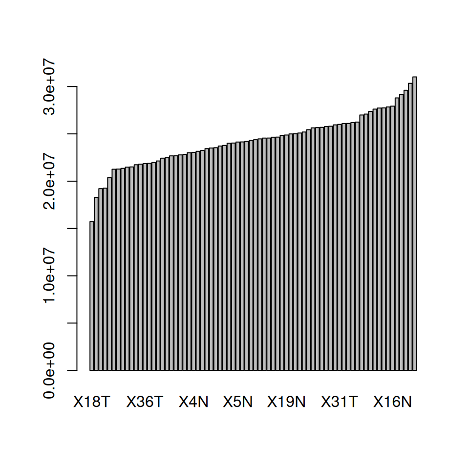

```r
barplot(mycolsums)
```

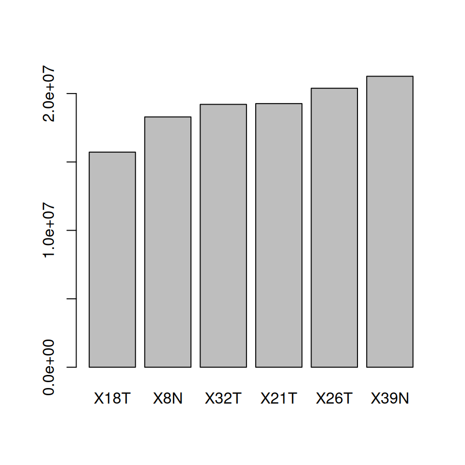

```r
barplot(head(mycolsums))
```

# Does this dataset need filtering of lowly expressed genes?

There are ~60k genes in the main annotation sets. We can count the number of rows to see how many genes included in this dataset.

I also run my own threshold, which is average of 10 reads per sample.

```r
dim(xa)
```

```
## [1] 18745    74
```

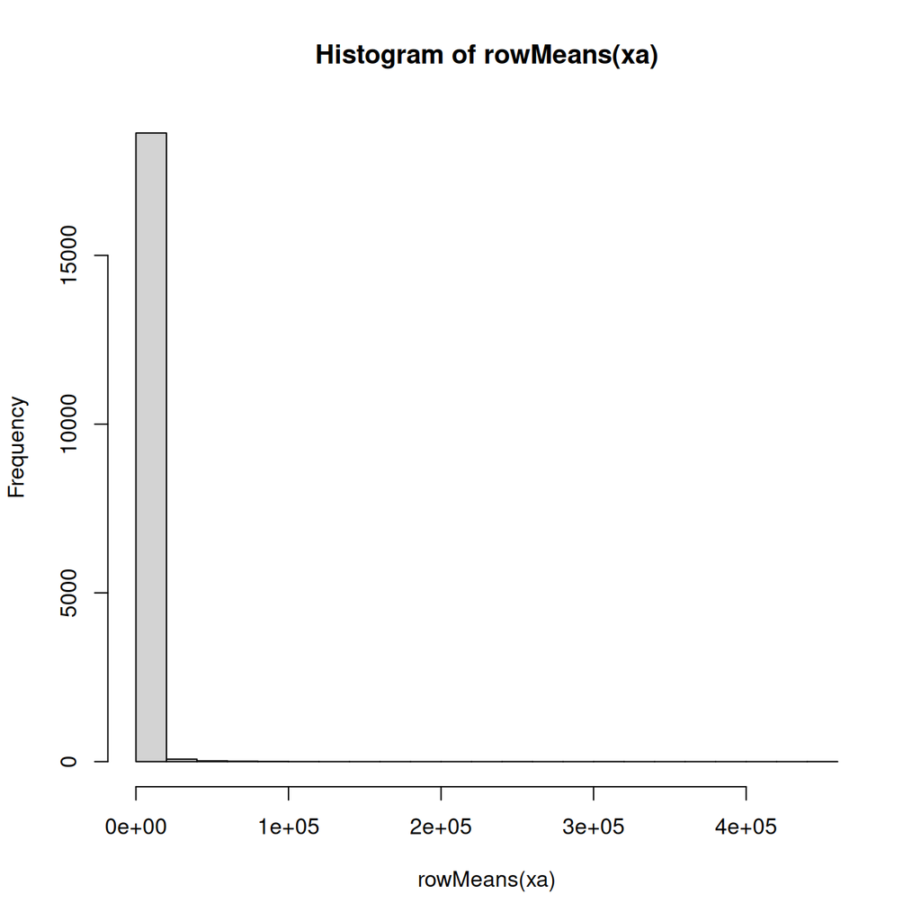

```r
hist(rowMeans(xa))
```

```r
table(rowMeans(xa)>=10)
```

```
##
## FALSE  TRUE
##  2309 16436
```

```r
xf <- xa[which(rowMeans(xa)>=10),]
dim(xa)
```

```
## [1] 18745    74
```

```r
dim(xf)
```

```
## [1] 16436    74
```

# Principal component analysis

Use PCA to understand the overall variation between samples in the dataset.

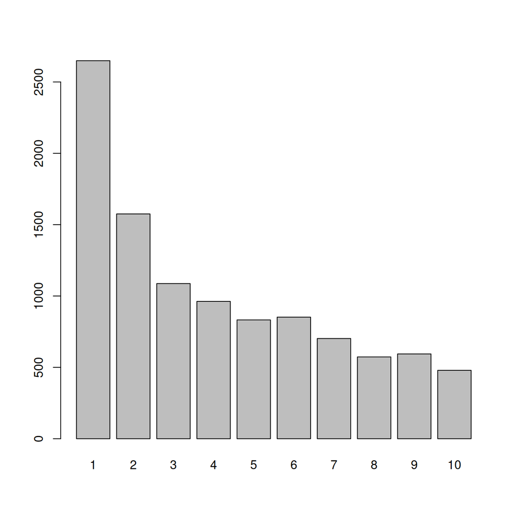

```r
mds <- cmdscale(dist(t(scale(xf))),k=10)
barplot(colSums(abs(mds)),names.arg = 1:10)
```

```r
head(mds)
```

```
##            [,1]       [,2]        [,3]       [,4]       [,5]        [,6]
## X10N  37.643694 -13.024427   0.8597808   4.097087   6.112696  10.7146140
## X10T -76.198299 -19.565410 -12.7071833  -4.364407 -15.251200  -0.5565757
## X11N  30.689243  -1.139396  -1.9729685  -6.541190  -4.298140  -2.8939500
## X11T -38.586767  -1.714293  34.3064374  -4.932127  16.569860  17.1527763
## X12N  38.975575  -6.187959 -10.0227906 -12.146277 -12.417868 -10.0294316
## X12T   3.294181  45.630846 -38.5169987  -8.184535 -29.904639  12.8409121
##            [,7]       [,8]       [,9]       [,10]
## X10N   7.568131  -3.935890  5.9196796   8.1464807
## X10T -24.416829 -14.702973 10.6437095   6.0036817
## X11N  -1.875214   3.404213  0.3012157  -0.1634874
## X11T  -4.899219   2.537063 -4.3955324 -10.1840018
## X12N  -3.669772   1.359340  1.6358922   1.5074445
## X12T  -3.015237   2.774796 -1.9950542   5.0620557
```

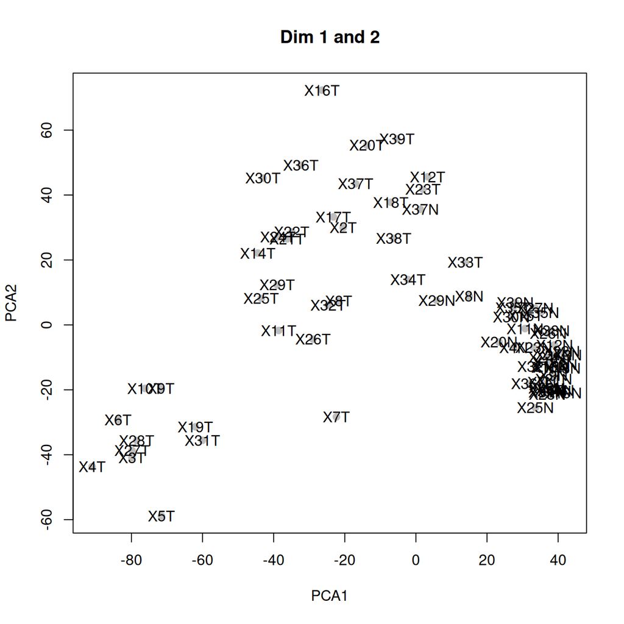

```r
plot(mds[,1:2],pch=19,col="gray",
     main="Dim 1 and 2",xlab="PCA1",ylab="PCA2")
text(mds[,1],mds[,2],labels = colnames(xf))
```

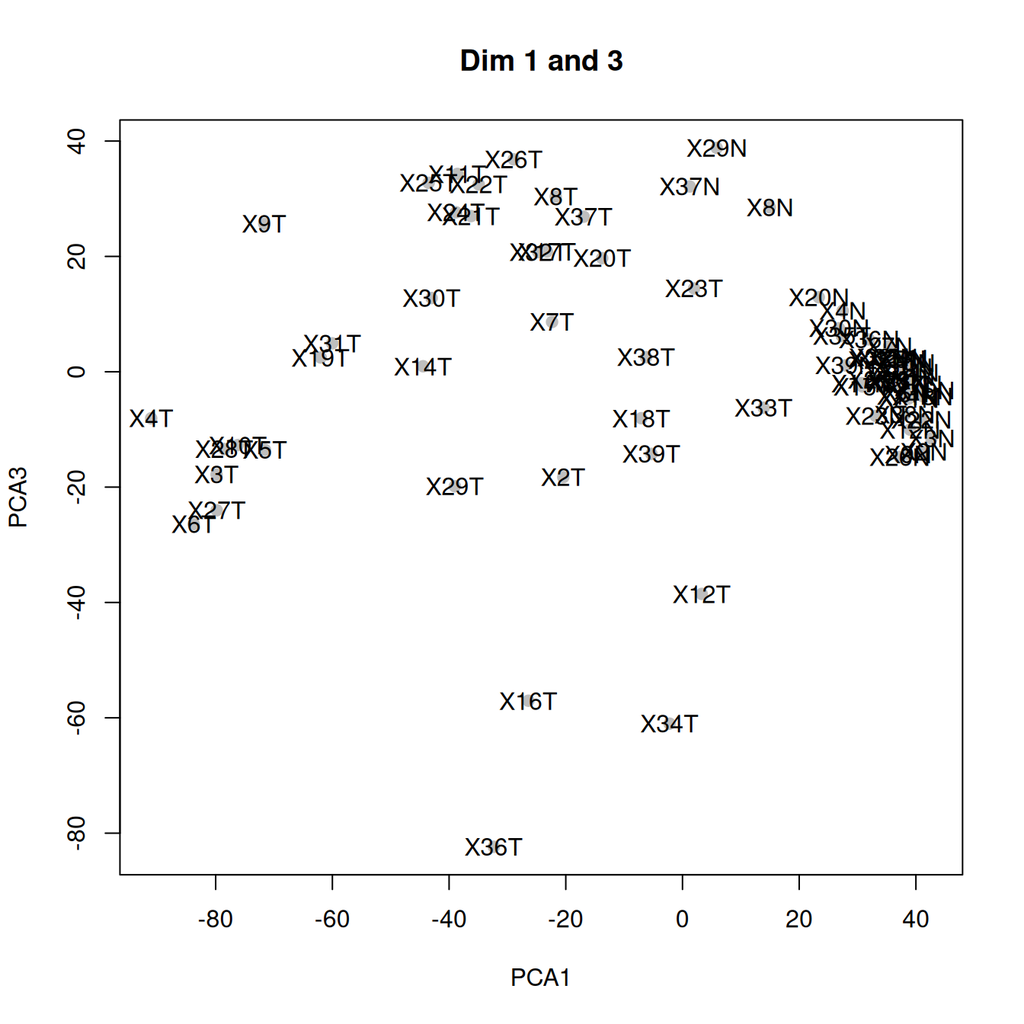

```r
plot(mds[,c(1,3)],pch=19,col="gray",
      main="Dim 1 and 3",xlab="PCA1",ylab="PCA3")
text(mds[,1],mds[,3],labels = colnames(xf))
```

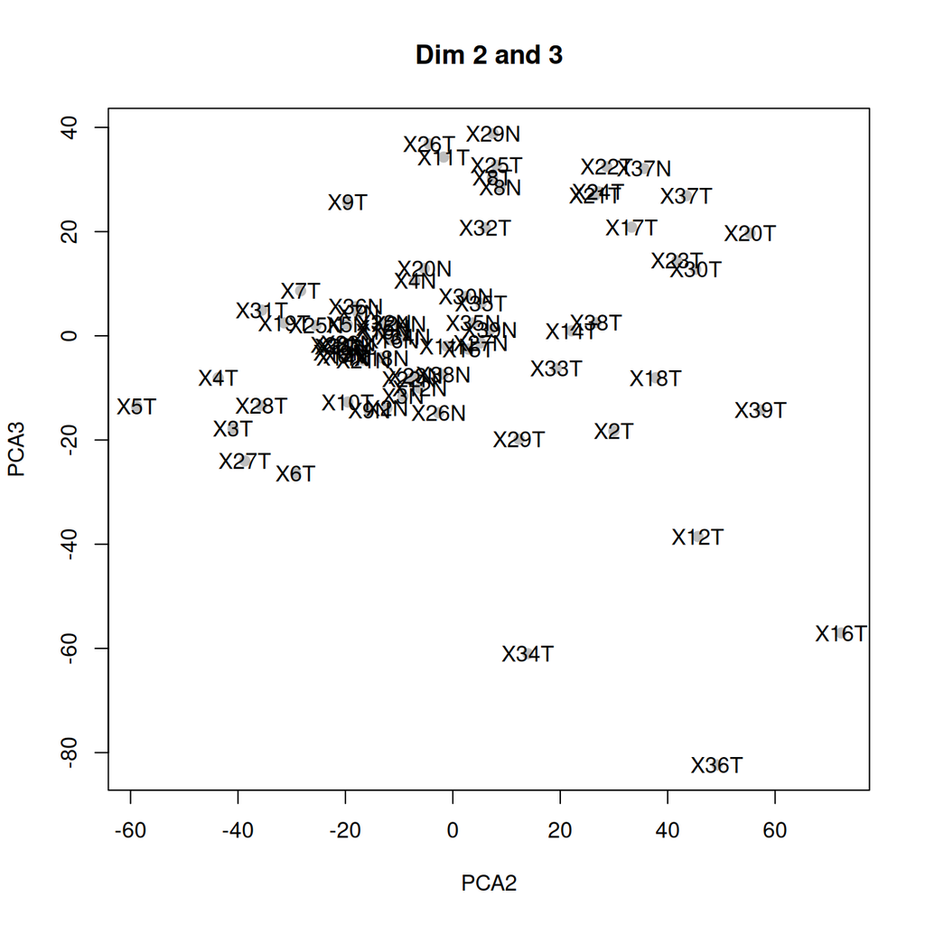

```r
plot(mds[,2:3],pch=19,col="gray",
      main="Dim 2 and 3",xlab="PCA2",ylab="PCA3")
text(mds[,2],mds[,3],labels = colnames(xf))
```

# Curate samplesheet

The samplesheet is the sample level metadata, which we need for the differential expression step.

```r
ss <- as.data.frame(colnames(xa))
head(ss)
```

```
##   colnames(xa)
## 1         X10N
## 2         X10T
## 3         X11N
## 4         X11T
## 5         X12N
## 6         X12T
```

```r
ss$tumor <- as.numeric(grepl("T",ss[,1]))

ss$patient <- gsub("T","" , gsub("N","",ss[,1]))

rownames(ss) <- ss[,1]

head(ss)
```

```
##      colnames(xa) tumor patient
## X10N         X10N     0     X10
## X10T         X10T     1     X10
## X11N         X11N     0     X11
## X11T         X11T     1     X11
## X12N         X12N     0     X12
## X12T         X12T     1     X12
```

## DE

We will use DESeq2 for differential expression.

```r
dds <- DESeqDataSetFromMatrix(countData = xf , colData=ss, design = ~ patient + tumor)
```

```
##   the design formula contains one or more numeric variables with integer values,
##   specifying a model with increasing fold change for higher values.
##   did you mean for this to be a factor? if so, first convert
##   this variable to a factor using the factor() function
```

```r
res <- DESeq(dds)
z <- results(res)
vsd <- vst(dds, blind=FALSE)
zz <- cbind(as.data.frame(z),assay(vsd))
dge <- as.data.frame(zz[order(zz$pvalue),])

head(dge) |> kbl(caption="Top significant genes") |> kable_paper("hover", full_width = F)
```

Top significant genes

|  | baseMean | log2FoldChange | lfcSE | stat | pvalue | padj | X10N | X10T | X11N | X11T | X12N | X12T | X14N | X14T | X15N | X15T | X16N | X16T | X17N | X17T | X18N | X18T | X19N | X19T | X20N | X20T | X21N | X21T | X22N | … |
| --- | --- | --- | --- | --- | --- | --- | --- | --- | --- | --- | --- | --- | --- | --- | --- | --- | --- | --- | --- | --- | --- | --- | --- | --- | --- | --- | --- | --- | --- | --- |
| PDK1 | 937.9546 | 2.135424 | 0.1258421 | 16.96908 | 0 | 0 | 8.650724 | 10.642692 | 8.967844 | 10.498565 | 8.134786 | 10.591653 | 8.785903 | 11.14347 | 8.485555 | 10.412894 | 8.189842 | 10.296493 | 8.159750 | 10.280791 | 8.159321 | 10.781402 | 8.458943 | 10.425273 | 8.240900 | 10.331761 | 8.397134 | 10.466147 | 8.421420 | … |
| SPP1 | 17975.1510 | 4.417666 | 0.2693309 | 16.40237 | 0 | 0 | 9.802055 | 14.176006 | 10.870985 | 16.825314 | 8.688407 | 12.657360 | 10.557322 | 14.38728 | 9.522463 | 10.686337 | 10.352215 | 12.227207 | 7.823136 | 14.615519 | 8.604498 | 15.602296 | 7.498959 | 13.301173 | 10.576368 | 14.946618 | 8.665934 | 13.679833 | 8.535472 | … |
| AGER | 11559.6967 | -5.477084 | 0.3355681 | -16.32183 | 0 | 0 | 15.168655 | 6.893846 | 12.872945 | 7.774126 | 14.211504 | 12.702896 | 14.940987 | 11.01977 | 13.667223 | 12.246874 | 14.571089 | 12.406805 | 15.184985 | 8.875605 | 14.333295 | 9.462969 | 14.876306 | 7.152258 | 13.901056 | 11.208358 | 15.016984 | 7.368619 | 14.376976 | … |
| KRT6A | 101501.5369 | 6.204478 | 0.3804130 | 16.30985 | 0 | 0 | 9.193072 | 18.281839 | 9.516516 | 16.677201 | 5.958339 | 6.729277 | 12.537963 | 17.66984 | 6.000258 | 9.543121 | 6.498843 | 9.294537 | 6.309422 | 7.986419 | 7.160003 | 12.763140 | 5.583972 | 18.514452 | 6.573442 | 8.585020 | 5.795055 | 10.728299 | 5.594051 | … |
| MMP12 | 1248.2652 | 4.513220 | 0.2774515 | 16.26670 | 0 | 0 | 8.657790 | 12.099376 | 6.731019 | 9.882017 | 5.567395 | 7.050066 | 6.715331 | 10.78122 | 7.200864 | 9.530651 | 8.358858 | 9.221172 | 5.939377 | 12.950840 | 6.216791 | 10.401415 | 4.961707 | 13.143017 | 6.620989 | 9.432495 | 6.324553 | 11.631126 | 6.749005 | … |
| KRT16 | 6223.7362 | 5.838103 | 0.3652821 | 15.98245 | 0 | 0 | 5.963193 | 13.704380 | 7.391931 | 12.286157 | 4.995210 | 6.307710 | 7.257980 | 12.00832 | 5.181189 | 6.695150 | 5.090391 | 7.000848 | 5.670905 | 9.215005 | 5.204919 | 11.382030 | 5.150114 | 12.312411 | 5.220550 | 6.160121 | 4.659063 | 8.918967 | 5.695141 | … |

## Heatmap visualisation

Heatmaps are great for showing high dimensional data.

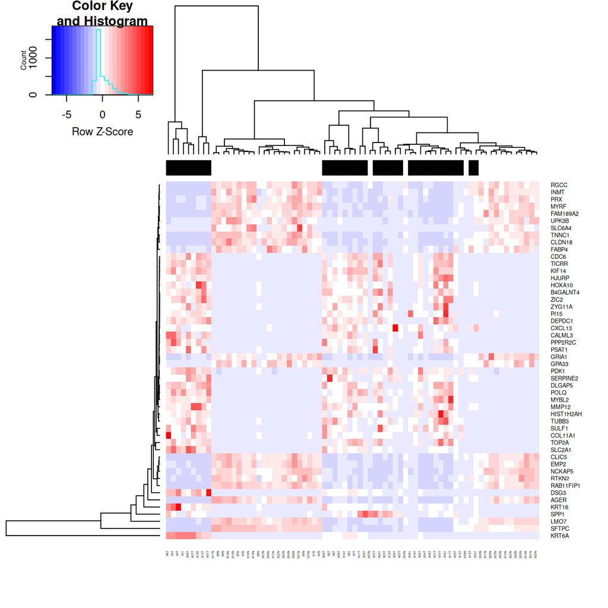

```r
topgenes <- head(rownames(dge),50)

colfunc <- colorRampPalette(c("blue", "white", "red"))

rpm <- apply(xf,2,function(x) {x/sum(x) * 1e6 } )

top <- rpm[which(rownames(rpm) %in% topgenes),]

csc = as.character(ss$tumor)

heatmap.2(as.matrix(top),trace="none",col=colfunc(25),scale="row",
    margins = c(6,6), cexRow=0.6, cexCol=0.3, ColSideColors=csc )
```

## Pathway enrichment analysis

Here, we’ll use the fgsea package on Reactome pathways.

```r
GMT="ReactomePathways_2025-10-15.gmt"

if ( ! file.exists(GMT) ) {
  download.file("https://ziemann-lab.net/public/bioinfo_workshop/ReactomePathways_2025-10-15.gmt",
    destfile=GMT)
}

gs <- gmtPathways("ReactomePathways_2025-10-15.gmt")
head(gs,3)
```

```
## $`2-LTR circle formation`
##  [1] "BANF1"   "HMGA1"   "LIG4"    "PSIP1"   "XRCC4"   "XRCC5"   "XRCC6"
##  [8] "gag"     "gag-pol" "rev"     "vif"     "vpr"     "vpu"
##
## $`3-Methylcrotonyl-CoA carboxylase deficiency`
## [1] "MCCC1" "MCCC2"
##
## $`3-hydroxyisobutyryl-CoA hydrolase deficiency`
## [1] "HIBCH"
```

```r
dge$stat[which(is.na(dge$stat))] <- 0 # substitute 0 for NA vals

stat <- dge$stat #use DESeq2 test stat for ranking genes
names(stat) <- rownames(dge) #attach gene names to values

fres <- fgsea(pathways=gs,stats=stat,minSize=5, nproc=4) #run fgsea
```

[output not shown]

```r
fsig <- subset(fres,padj<0.05) # subset significant sets
nrow(fsig)
```

```
## [1] 593
```

```r
fres <- fres[order(-abs(fres$ES)),]

head(subset(fres,padj<0.05 & ES>0),20) %>%
  kbl(caption="mRNA upregulated pathways") %>%
  kable_styling("hover",full_width=FALSE)
```

mRNA upregulated pathways

| pathway | pval | padj | log2err | ES | NES | size | leadingEdge |
| --- | --- | --- | --- | --- | --- | --- | --- |
| Phosphorylation of Emi1 | 0.0000001 | 0.0000010 | 0.7195128 | 0.9725996 | 2.113315 | 6 | CDC20, C…. |
| TFAP2A acts as a transcriptional repressor during retinoic acid induced cell differentiation | 0.0001233 | 0.0010043 | 0.5188481 | 0.9202118 | 1.896470 | 5 | MYBL2, T…. |
| Unwinding of DNA | 0.0000000 | 0.0000005 | 0.7337620 | 0.8885573 | 2.391155 | 12 | CDC45, G…. |
| G2/M DNA replication checkpoint | 0.0000734 | 0.0006524 | 0.5384341 | 0.8871306 | 2.031745 | 7 | CCNA2, C…. |
| Condensation of Prometaphase Chromosomes | 0.0000010 | 0.0000141 | 0.6435518 | 0.8575790 | 2.263163 | 11 | NCAPH, C…. |
| p75NTR negatively regulates cell cycle via SC1 | 0.0006403 | 0.0039264 | 0.4772708 | 0.8542886 | 1.856243 | 6 | HDAC2, N…. |
| TFAP2 (AP-2) family regulates transcription of cell cycle factors | 0.0033760 | 0.0157255 | 0.4317077 | 0.8464129 | 1.744378 | 5 | TFAP2A, …. |
| Vasopressin-like receptors | 0.0077258 | 0.0308589 | 0.4070179 | 0.8144183 | 1.678440 | 5 | OXT, AVP…. |
| Regulation of gene expression in endocrine-committed (NEUROG3+) progenitor cells | 0.0100099 | 0.0378092 | 0.3807304 | 0.8063417 | 1.661795 | 5 | NKX2-2, …. |
| Polo-like kinase mediated events | 0.0000002 | 0.0000042 | 0.6901325 | 0.7966416 | 2.371978 | 16 | MYBL2, C…. |
| Proton-coupled monocarboxylate transport | 0.0056062 | 0.0236620 | 0.4070179 | 0.7887752 | 1.713892 | 6 | SLC16A1,…. |
| DNA replication initiation | 0.0013430 | 0.0073304 | 0.4550599 | 0.7877568 | 1.888483 | 8 | POLE2, P…. |
| Deposition of new CENPA-containing nucleosomes at the centromere | 0.0000000 | 0.0000000 | 0.8012156 | 0.7839504 | 2.622352 | 24 | HJURP, C…. |
| Nucleosome assembly | 0.0000000 | 0.0000000 | 0.8012156 | 0.7839504 | 2.622352 | 24 | HJURP, C…. |
| Defective pyroptosis | 0.0000653 | 0.0005945 | 0.5384341 | 0.7809912 | 2.101689 | 12 | EZH2, PR…. |
| E2F-enabled inhibition of pre-replication complex formation | 0.0005459 | 0.0034180 | 0.4772708 | 0.7806572 | 1.930470 | 9 | ORC6, CC…. |
| Condensation of Prophase Chromosomes | 0.0000764 | 0.0006752 | 0.5384341 | 0.7781689 | 2.094094 | 12 | CCNB1, P…. |
| CDC6 association with the ORC:origin complex | 0.0032812 | 0.0154267 | 0.4317077 | 0.7642007 | 1.832012 | 8 | CDC6, OR…. |
| DNA strand elongation | 0.0000000 | 0.0000000 | 0.8390889 | 0.7566933 | 2.705987 | 32 | CDC45, G…. |
| Activation of ATR in response to replication stress | 0.0000000 | 0.0000000 | 0.8870750 | 0.7462308 | 2.773970 | 37 | CDC6, CD…. |

```r
head(subset(fres,padj<0.05 & ES<0),20) %>%
  kbl(caption="mRNA downregulated pathways") %>%
  kable_styling("hover",full_width=FALSE)
```

mRNA downregulated pathways

| pathway | pval | padj | log2err | ES | NES | size | leadingEdge |
| --- | --- | --- | --- | --- | --- | --- | --- |
| Diseases associated with surfactant metabolism | 0.0000121 | 0.0001408 | 0.5933255 | -0.8749011 | -2.335023 | 9 | SFTPC, S…. |
| Defective CSF2RA causes SMDP4 | 0.0001831 | 0.0013736 | 0.5188481 | -0.8747946 | -2.157537 | 7 | SFTPC, S…. |
| Defective CSF2RB causes SMDP5 | 0.0001831 | 0.0013736 | 0.5188481 | -0.8747946 | -2.157537 | 7 | SFTPC, S…. |
| NOSTRIN mediated eNOS trafficking | 0.0014632 | 0.0079036 | 0.4550599 | -0.8734137 | -1.887229 | 5 | CAV1, NO…. |
| Classical antibody-mediated complement activation | 0.0030231 | 0.0144901 | 0.4317077 | -0.8501940 | -1.837057 | 5 | C1QA, C1…. |
| TGFBR3 regulates TGF-beta signaling | 0.0002235 | 0.0015796 | 0.5188481 | -0.8253627 | -2.113376 | 8 | ARRB1, T…. |
| Acyl chain remodeling of DAG and TAG | 0.0064068 | 0.0264517 | 0.4070179 | -0.8227138 | -1.777679 | 5 | PNPLA2, MGLL |
| Biosynthesis of Lipoxins (LX) | 0.0065721 | 0.0270272 | 0.4070179 | -0.8215246 | -1.775109 | 5 | ALOX5AP,…. |
| Erythrocytes take up oxygen and release carbon dioxide | 0.0007233 | 0.0043712 | 0.4772708 | -0.7970048 | -2.040764 | 8 | CA4, HBB…. |
| Translocation of ZAP-70 to Immunological synapse | 0.0000014 | 0.0000193 | 0.6435518 | -0.7697788 | -2.503245 | 17 | HLA-DRB5…. |
| Biosynthesis of EPA-derived SPMs | 0.0114831 | 0.0418570 | 0.3807304 | -0.7534388 | -1.746318 | 6 | LTA4H, A…. |
| RSK activation | 0.0137382 | 0.0489644 | 0.3807304 | -0.7532166 | -1.857685 | 7 | RPS6KA1,…. |
| Mucopolysaccharidoses | 0.0004370 | 0.0028038 | 0.4984931 | -0.7437490 | -2.131739 | 11 | HYAL1, I…. |
| Phosphorylation of CD3 and TCR zeta chains | 0.0000003 | 0.0000044 | 0.6749629 | -0.7429477 | -2.532022 | 20 | HLA-DRB5…. |
| Erythrocytes take up carbon dioxide and release oxygen | 0.0003732 | 0.0024623 | 0.4984931 | -0.7181737 | -2.105423 | 12 | CA4, HBB…. |
| O2/CO2 exchange in erythrocytes | 0.0003732 | 0.0024623 | 0.4984931 | -0.7181737 | -2.105423 | 12 | CA4, HBB…. |
| Neurotransmitter clearance | 0.0092184 | 0.0353317 | 0.3807304 | -0.7154626 | -1.831972 | 8 | SLC6A4, …. |
| Signaling by TGF-beta Receptor Complex in Cancer | 0.0092184 | 0.0353317 | 0.3807304 | -0.7151750 | -1.831235 | 8 | TGFBR2, …. |
| Phosphorylation of CLOCK, acetylation of BMAL1 (ARNTL) at target gene promoters | 0.0033789 | 0.0157255 | 0.4317077 | -0.7083690 | -1.964221 | 10 | CRY2, PE…. |
| MAPK1 (ERK2) activation | 0.0079905 | 0.0317941 | 0.3807304 | -0.6949324 | -1.854704 | 9 | IL6R, IL…. |

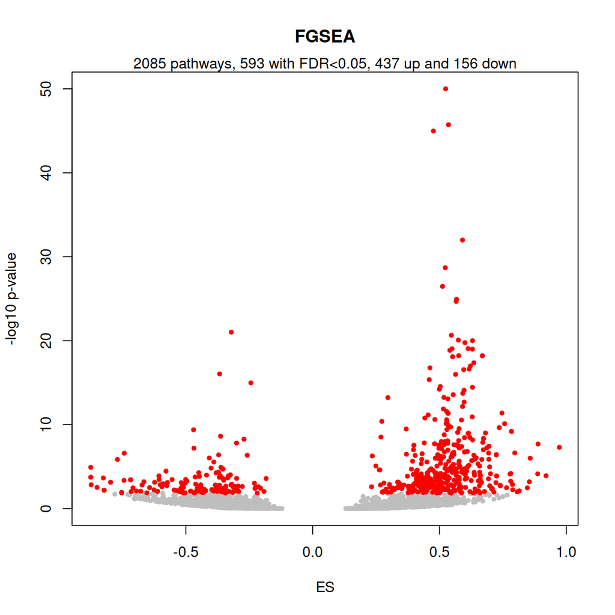

```r
NRES=nrow(fres)
NSIG=nrow(fsig)
NUP=nrow(subset(fsig,ES>0))
NDN=nrow(subset(fsig,ES<0))
HEADER=paste(NRES,"pathways,",NSIG,"with FDR<0.05,",NUP,"up and",NDN,"down")

plot(fres$ES,-log10(fres$pval),pch=19,cex=0.6,col="gray",
  xlab="ES",ylab="-log10 p-value",main="FGSEA")
points(fsig$ES,-log10(fsig$pval),cex=0.6,col="red",pch=19)
mtext(HEADER)
```

```r
save.image("w6_workflow.Rdata")
```